# Technology and Social Change

Lecture 4: Agricultural Revolution

Bogdan G. Popescu

bgpopescu@tec.mx

Tecnológico de Monterrey

# Puzzles and Objectives

## A Provocative Question

### Was Agriculture Humanity’s Worst Mistake?

- Diamond (1987): called agriculture a “catastrophe”
- Hunter-gatherers had more leisure, better nutrition
- Yet agriculture underlies all complex civilization
- Paradox: was it progress or a demographic trap?

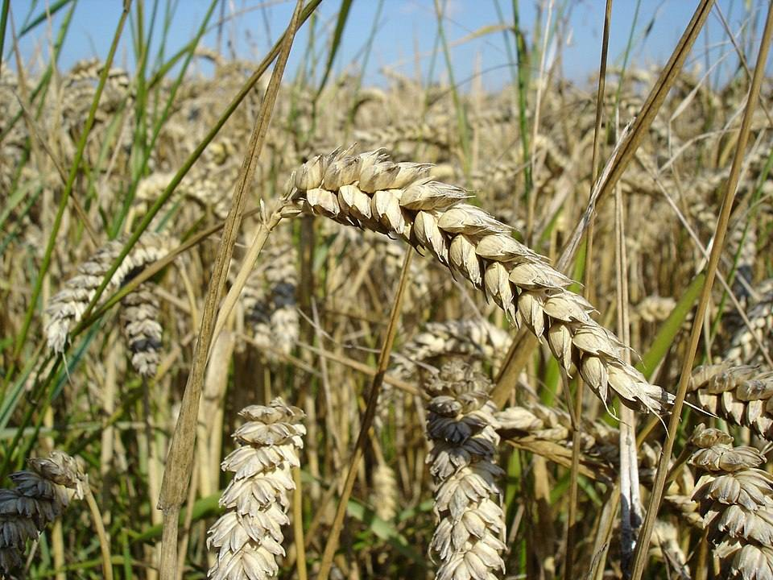

Wheat: the crop that changed human civilization — for better or worse. Photo: Bluemoose / Wikimedia Commons (CC BY-SA 3.0).

## Why Political Scientists Care

### Technology Shapes Political Possibility

- Agriculture created surplus: foundation of state power
- Sedentism enabled taxation and territorial control
- Property systems emerged to manage resources
- Early institutional choices persist for millennia

## Agriculture as Technological Revolution

### More Than a Change in Diet

- Technology = systematic knowledge transforming nature
- New tools, techniques, knowledge, social organization
- Enabled population growth by order of magnitude
- Created entirely new social forms

## Learning Objectives

1. Explain agriculture as technological transformation
2. Trace: surplus → specialization → hierarchy → institutions
3. Compare agricultural transitions across regions
4. Evaluate progress vs. trap interpretations
5. Connect agricultural origins to long-run development

## So What?

Agriculture was not just a dietary shift — it was the **first technological revolution** that restructured all human social organization.

> The analytical tools we build here will apply to every subsequent technological transformation in this course.

**Next:** What conceptual framework helps us analyze this?

# Conceptual Framework

## Defining Technology

### Beyond Gadgets and Machines

- “A means to fulfill a human purpose” (Arthur, 2009)
- Includes knowledge, practices, organization — not just tools
- Technologies are *combinatorial*: built from existing pieces
- Technologies are *recursive*: enable further innovation

## The Cognitive Revolution (~70,000 BCE)

### What Came Before Agriculture

- Language, abstract thought, large-scale cooperation
- Enabled culture, planning, and social learning
- Limited to foraging bands (20–150 people)
- Material constraints: no surplus, no accumulation

[figure not shown]

Lascaux cave paintings (c. 17,000 BCE): evidence of symbolic thought and complex communication long before agriculture. Source: Wikimedia Commons (public domain).

## The Agricultural Revolution (~10,000 BCE)

### A Package of Transformations

- Domestication of plants and animals
- Sedentary settlement replaces nomadic movement
- Population density increases dramatically
- Storage enables surplus and accumulation

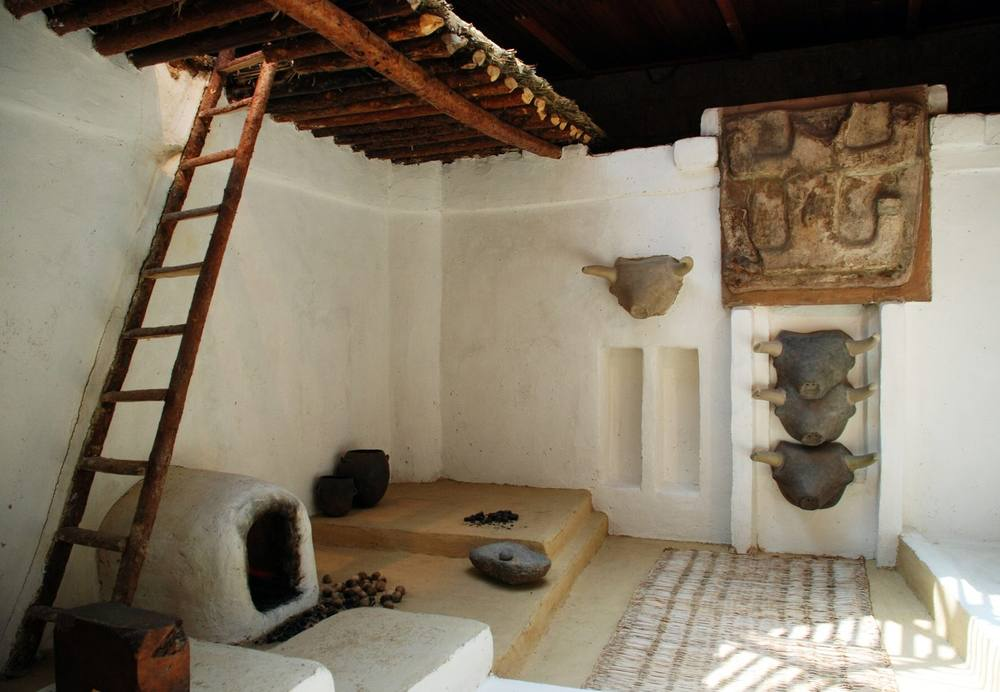

Çatalhöyük (southern Turkey, c. 7500 BCE): one of the earliest known proto-urban settlements, housing up to 10,000 people. Source: Wikimedia Commons (public domain).

## Case Evidence: Çatalhöyük

[video not shown]

Source: https://www.youtube.com/watch?v=5EZ4Z4v1JAE

1. Why were there no streets in Çatalhöyük?  
2. What evidence suggests this society was egalitarian?  
3. Why did they bury their dead under the floors?  
4. What role did wild animals play beyond food?

## The Core Causal Chain

### Surplus → Specialization → Hierarchy → Institutions

```
%%{init: {'theme': 'base', 'themeVariables': {'fontSize': '22px', 'primaryColor': '#4a7c6f', 'primaryTextColor': '#1e293b', 'primaryBorderColor': '#334155', 'lineColor': '#334155', 'secondaryColor': '#f9fafb', 'tertiaryColor': '#f9fafb'}, 'flowchart': {'useMaxWidth': true, 'nodeSpacing': 50, 'rankSp…
flowchart LR
    A["<b>SURPLUS</b><br/>Storage &amp;<br/>accumulation"] --> B["<b>SPECIALIZATION</b><br/>Division of labor<br/>&amp; new roles"]
    B --> C["<b>HIERARCHY</b><br/>Elites emerge<br/>&amp; unequal power"]
    C --> D["<b>INSTITUTIONS</b><br/>Property rights<br/>&amp; political order"]
    D -->|"Feedback: institutions<br/>stabilize extraction"| A

    style A fill:#4a7c6f,color:#f9fafb,stroke:#334155
    style B fill:#4a7c6f,color:#f9fafb,stroke:#334155
    style C fill:#b44527,color:#f9fafb,stroke:#334155
    style D fill:#b44527,color:#f9fafb,stroke:#334155
```

Source: Author’s illustration based on Harari (2015) and Acemoglu & Robinson (2012).

## Class Exercise 1

### Technology and Surplus Today

**Prompt:** In pairs, identify a modern technology that follows the surplus → specialization → hierarchy pattern. What “surplus” does it create? Who controls it?

*Think about platforms like Uber, Amazon, or social media.*

**Time: 5 minutes**

# Comparative Evidence

## Independent Agricultural Revolutions

### Multiple Origins, Similar Consequences

- Agriculture emerged independently at least 7–11 times
- Fertile Crescent (~9,000 BCE), China (~8,000 BCE)
- Mesoamerica (~7,000 BCE), New Guinea (~7,000 BCE)
- Similar causal chains despite different crops and contexts

## Agricultural Origins Worldwide

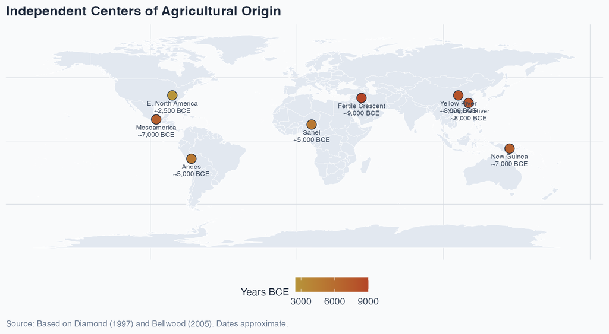

Figure 1: Independent centers of agricultural origin. Dates approximate.

## Case 1 — The Fertile Crescent

### Why Here? Why Then?

- Favorable climate: wet winters, dry summers
- Wild ancestors of wheat, barley, sheep, goats
- Climate shift at end of Younger Dryas (~9700 BCE)
- Population grew 10–100× in agricultural zones

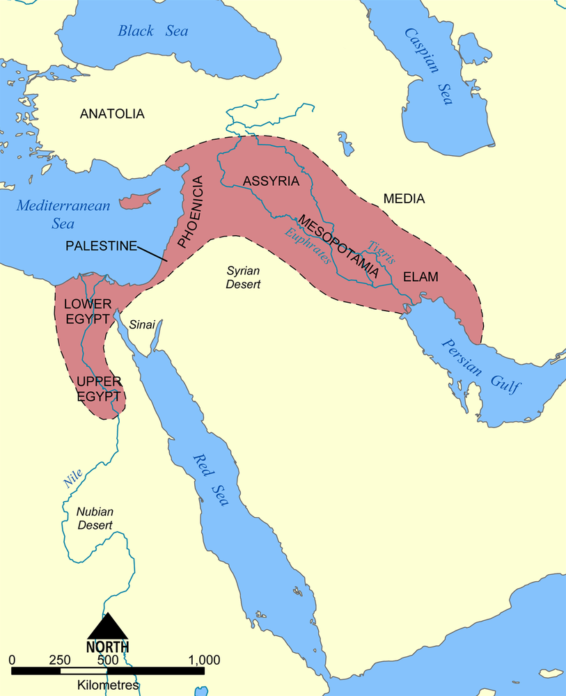

The Fertile Crescent: the arc of territory stretching from the Nile to the Tigris–Euphrates where agriculture first emerged. Source: Wikimedia Commons (public domain).

## Case 1 — Political Organization

### From Villages to States

- Early cities: Uruk (40,000+ by 3100 BCE)
- First states: taxation, bureaucracy, armies
- First writing: accounting for surplus (cuneiform)
- Temple economies: centralized redistribution

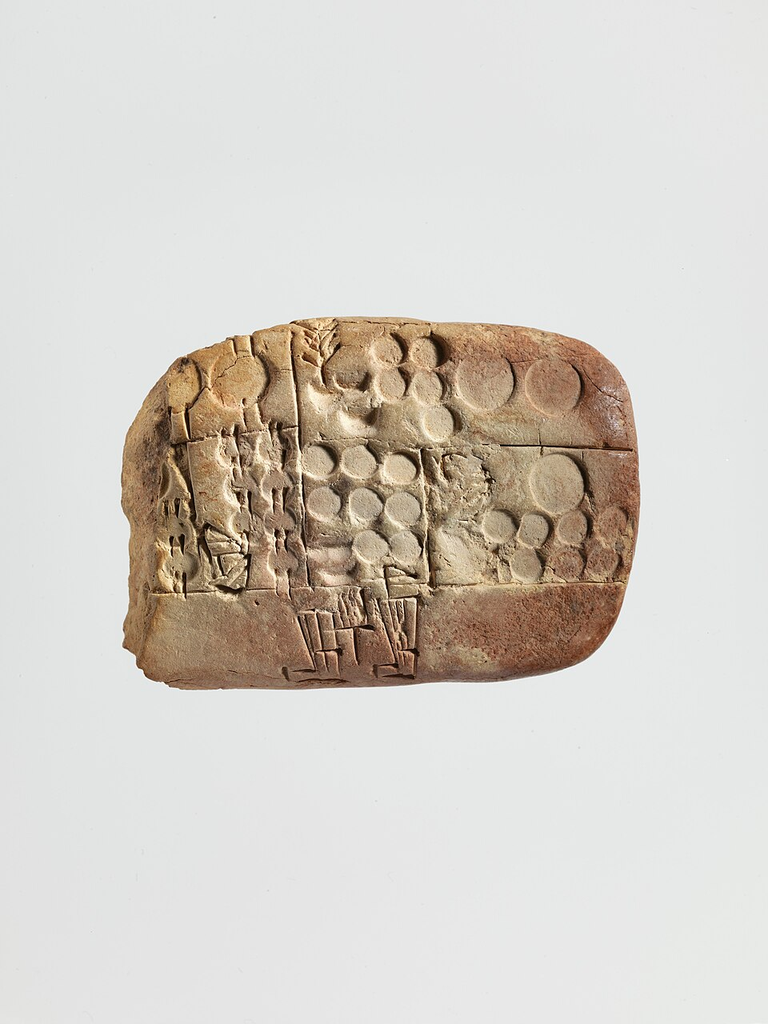

Cuneiform tablet recording barley and emmer distribution (c. 3100–2900 BCE). Writing began as accounting for agricultural surplus. Source: Metropolitan Museum of Art (CC0).

## Case 2 — China

### Two Rivers, Two Crops

- Yellow River (north): millet (~8,000 BCE)
- Yangtze River (south): rice (~8,000 BCE)
- Neolithic villages: Banpo, Hemudu (5000+ BCE)
- Bronze Age states: Shang dynasty (~1600 BCE)
- “Hydraulic hypothesis”: irrigation demands coordination

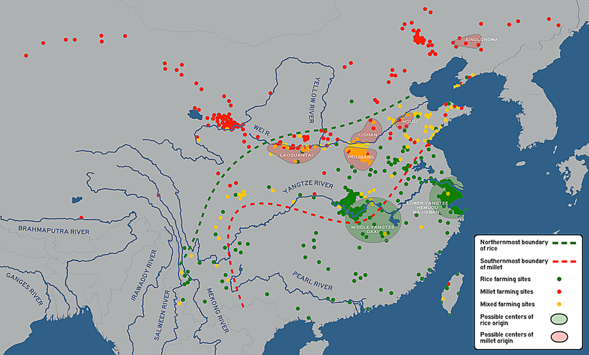

Distribution of rice (south) and millet (north) farming sites in Neolithic China, showing two distinct agricultural zones. Source: Obsidian Soul / Wikimedia Commons (CC0).

## Case 2 — Property and Institutions

### Distinctive Chinese Features

- Well-field system: communal + private land
- Early census and taxation systems
- Ancestor worship tied to land inheritance
- Bureaucratic selection evolved into examinations

## Case 3 — Mesoamerica

### Different Constraints, Similar Outcomes

- Maize domestication began ~9,000 years ago from teosinte
- “Three sisters” polyculture (Maize [corn], Beans, Squash): nutritionally complete
- No large domesticated animals for labor or transport
- Cities: Teotihuacan (100,000+ by 400 CE)
- Human labor substituted for animal labor

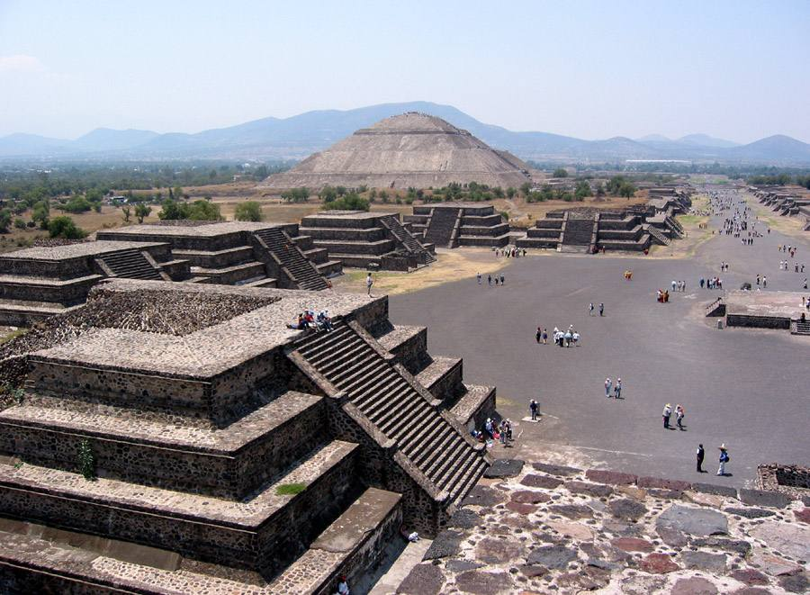

Teotihuacan, Mexico: the Pyramids of the Sun and Moon. By 400 CE this city housed over 100,000 people — one of the largest in the ancient world. Source: Wikimedia Commons (public domain).

## Case 3 — Political Organization

### Complex States Without the Wheel

- City-states and empires (Maya, Aztec)
- Tribute systems: surplus extraction at scale
- Sophisticated calendars and writing (Maya glyphs)
- Priest-king rulers: religious and political authority fused

## Cross-Regional Comparison

| Feature | Fertile Crescent | China | Mesoamerica |
| --- | --- | --- | --- |
| Key crops | Wheat, barley | Rice, millet | Maize, squash |
| Draft animals | Yes | Yes | No |
| First cities | ~3500 BCE | ~2000 BCE | ~500 BCE |
| Writing origin | Accounting | Divination | Calendrics |
| State type | Bureaucratic | Centralized | Tribute-based |

Source: Author’s summary based on Diamond (1997) and Trigger (2003).

## Population Growth After Agriculture

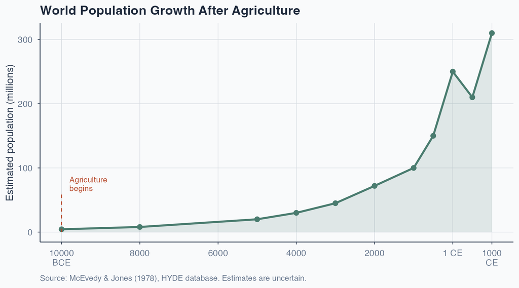

Figure 2: World population growth after the agricultural revolution.

## From Agriculture to State Formation

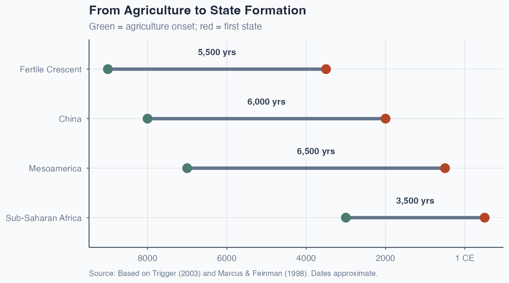

Figure 3: Lag between agriculture onset and first state formation.

## Agriculture Made Inequality Possible

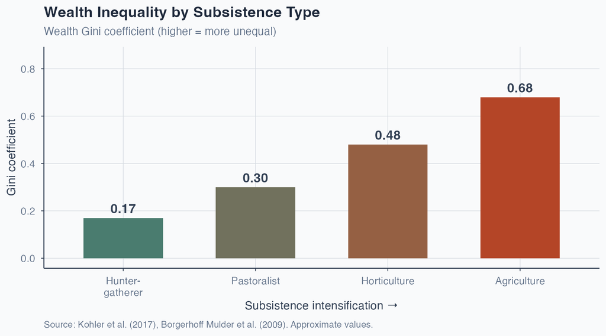

Figure 4: Wealth Gini rises with subsistence intensification.

## Class Exercise 2

### Counterfactual Reasoning

**Prompt:** Compare the Fertile Crescent and Mesoamerica. If Mesoamerica had possessed draft animals, how might its development trajectory have differed? Identify two specific mechanisms.

*Consider: labor productivity, transportation, military technology, disease ecology.*

**Time: 5 minutes**

# Competing Interpretations

## Two Competing Interpretations

**Progress (traditional view)**

- More food → more people → more innovation
- Precondition for science, philosophy, civilization
- Progressive narrative: foraging → farming → modernity

**Trap (revisionist challenge)**

- Harari: agriculture made most humans worse off
- Harder work, worse nutrition, more disease
- More inequality, violence, and coercion

## The “Trap” Mechanisms

### Why Populations Couldn’t Go Back

- Population growth outstripped foraging carrying capacity
- Sedentism created property that couldn’t be abandoned
- Knowledge of foraging was lost over generations
- States coerced farming through taxation and force

## Model A — Environmental Determinism

```
%%{init: {'theme': 'base', 'themeVariables': {'fontSize': '20px', 'primaryColor': '#4a7c6f', 'primaryTextColor': '#1e293b', 'primaryBorderColor': '#334155', 'lineColor': '#334155', 'secondaryColor': '#f9fafb', 'tertiaryColor': '#f9fafb'}, 'flowchart': {'useMaxWidth': true, 'nodeSpacing': 50, 'rankSp…
flowchart LR
    A["<b>GEOGRAPHY</b><br/>Climate, species,<br/>continental axes"] --> B["<b>AGRICULTURE<br/>TIMING</b><br/>Early vs. late<br/>adoption"]
    B --> C["<b>TECHNOLOGY<br/>SPREAD</b><br/>Head-start<br/>advantages"]
    C --> D["<b>DEVELOPMENT<br/>OUTCOMES</b><br/>Rich vs.<br/>poor today"]

    style A fill:#4a7c6f,color:#f9fafb,stroke:#334155
    style B fill:#4a7c6f,color:#f9fafb,stroke:#334155
    style C fill:#4a7c6f,color:#f9fafb,stroke:#334155
    style D fill:#b7943a,color:#1e293b,stroke:#334155
```

Source: Author’s illustration based on Diamond (1997). Geography determines outcomes directly.

## Model B — Institutional Mediation

```
%%{init: {'theme': 'base', 'themeVariables': {'fontSize': '20px', 'primaryColor': '#b44527', 'primaryTextColor': '#1e293b', 'primaryBorderColor': '#334155', 'lineColor': '#334155', 'secondaryColor': '#f9fafb', 'tertiaryColor': '#f9fafb'}, 'flowchart': {'useMaxWidth': true, 'nodeSpacing': 50, 'rankSp…
flowchart LR
    A["<b>GEOGRAPHY</b><br/>Climate &amp;<br/>resources"] --> B["<b>AGRICULTURE<br/>TIMING</b><br/>Early vs. late"]
    B --> C["<b>INSTITUTIONS</b><br/>Extractive vs.<br/>inclusive"]
    C --> D["<b>DEVELOPMENT<br/>OUTCOMES</b><br/>Divergent paths"]
    E["<b>CRITICAL<br/>JUNCTURES</b><br/>Agency &amp;<br/>contingency"] --> C

    style A fill:#4a7c6f,color:#f9fafb,stroke:#334155
    style B fill:#4a7c6f,color:#f9fafb,stroke:#334155
    style C fill:#b44527,color:#f9fafb,stroke:#334155
    style D fill:#b7943a,color:#1e293b,stroke:#334155
    style E fill:#b44527,color:#f9fafb,stroke:#334155
```

Source: Author’s illustration based on Acemoglu & Robinson (2012). Institutions mediate geography’s effects.

## Evaluating the Competing Views

### Synthesis and Assessment

- Both progress and trap narratives capture partial truths
- Environment matters for initial conditions
- Institutions determine long-run outcomes
- Path dependence is real but not deterministic
- Human agency operates within structural constraints

# Modern Relevance

## Agricultural Origins and Development Today

### The Long Shadow of Early Farming

- Countries with longer agricultural history: higher GDP
- Putterman & Weil (2010): longer agricultural history correlates with significantly higher income
- Mechanism: head start in state formation and technology
- Correlation, not necessarily causation

## Agricultural Ancestry and Modern Income

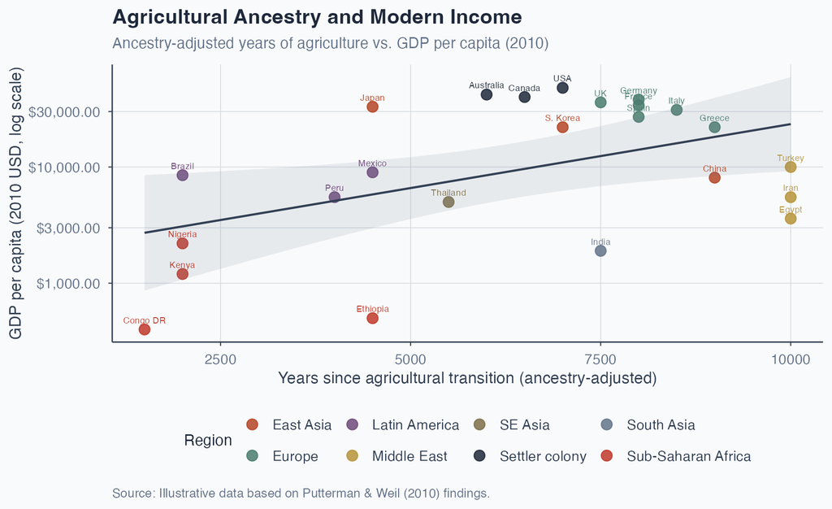

Figure 5: Ancestry-adjusted agricultural history vs. GDP per capita.

## From Agricultural to Industrial Revolution

### Continuity and Transformation

- Industrial revolution: another technology → surplus → institutions cycle
- Agricultural institutions shaped industrial possibilities
- England’s agricultural revolution preceded industrial takeoff
- Same analytical template applies across eras

# Discussion and Synthesis

## Key Takeaways

1. **Agriculture as technology**: a transformative package, not just farming
2. **The causal chain**: surplus → specialization → hierarchy → institutions
3. **Comparative evidence**: similar patterns across independent cases
4. **Competing views**: progress vs. trap; environment vs. institutions
5. **Path dependence**: early choices persist but do not fully determine outcomes

## The Full Analytical Framework

```
%%{init: {'theme': 'base', 'themeVariables': {'fontSize': '20px', 'primaryColor': '#4a7c6f', 'primaryTextColor': '#1e293b', 'primaryBorderColor': '#334155', 'lineColor': '#334155', 'secondaryColor': '#f9fafb', 'tertiaryColor': '#f9fafb'}, 'flowchart': {'useMaxWidth': true, 'nodeSpacing': 40, 'rankSp…
flowchart LR
    A["<b>GEOGRAPHY</b><br/>Climate &amp;<br/>species"] --> C["<b>AGRICULTURAL<br/>REVOLUTION</b><br/>Technology"]
    B["<b>COGNITION</b><br/>Language &amp;<br/>abstract thought"] --> C
    C --> D["<b>CAUSAL CHAIN</b><br/>Surplus → Hierarchy<br/>→ Institutions"]
    D --> E["<b>LONG-RUN<br/>CONSEQUENCES</b><br/>States, inequality,<br/>path dependence"]
    E --> F["<b>PROGRESS<br/>VIEW</b>"]
    E --> G["<b>TRAP<br/>VIEW</b>"]

    style A fill:#4a7c6f,color:#f9fafb,stroke:#334155
    style B fill:#4a7c6f,color:#f9fafb,stroke:#334155
    style C fill:#b44527,color:#f9fafb,stroke:#334155
    style D fill:#b44527,color:#f9fafb,stroke:#334155
    style E fill:#b7943a,color:#1e293b,stroke:#334155
    style F fill:#4a7c6f,color:#f9fafb,stroke:#334155
    style G fill:#b44527,color:#f9fafb,stroke:#334155
```

Source: Author’s synthesis of lecture framework.

# References

## References

Acemoglu, D., & Robinson, J. A. (2012). Why nations fail: The origins of power, prosperity, and poverty. Crown.

Arthur, W. B. (2009). The nature of technology: What it is and how it evolves. Free Press.

Bellwood, P. (2005). First farmers. Blackwell.

Diamond, J. (1997). Guns, germs, and steel: The fates of human societies. W. W. Norton & Company.

Harari, Y. N. (2015). Sapiens: A brief history of humankind. Harper.

Feinman, G. M., & Marcus, J. (1998). *Archaic States*. SAR Press.

McEvedy, C., & Jones, R. (1978). Atlas of world population history. Penguin.

North, D. C. (1990). Institutions, institutional change and economic performance. Cambridge University Press.

Scott, J. C. (2017). Against the grain: A deep history of the earliest states. Yale University Press.

Trigger, B. G. (2003). Understanding early civilizations. Cambridge University Press.

## References

Borgerhoff Mulder, M., Fazzio, I., Irons, W., & others. (2009). Intergenerational wealth transmission and the dynamics of inequality in small-scale societies. Science, 326(5953), 682–688.

Kohler, T. A., Smith, M. E., Bogaard, A., Feinman, G. M., Peterson, C. E., Betzenhauser, A., Pailes, M., Stone, E. C., Prentiss, A. M., Dennehy, T. J., Ellyson, L. J., Nicholas, L. M., Faulseit, R. K., Styring, A., & Whitlam, J. (2017). Greater post-Neolithic wealth disparities in Eurasia than in North America and Mesoamerica. Nature, 551(7682), 619–622.

Putterman, L., & Weil, D. N. (2010). Post-1500 population flows and the long-run determinants of economic growth and inequality. Quarterly Journal of Economics, 125(4), 1627–1682.

Diamond, J. (1987). The worst mistake in the history of the human race. Discover, 8(5), 64–66.